# Primer Parcial

Jauri Cortes Cardenas | Paula Burbano Aponte | Anyi Rodriguez Suarez | David Daza Jaimes

2024-03-11

## 1. Carga de archivo xlsx con la libreria readxl.

```r
d_olimpicos <- read_excel("Olimpicos Atenas 2004.xlsx")

set.seed(1858)
ds_olimpicos <- d_olimpicos[sample(1:nrow(d_olimpicos), size=200), ]
```

```r
ds_olimpicos$ID <- NULL

ds_olimpicos$NOC <- NULL

ds_olimpicos$Games <- NULL

ds_olimpicos$Year <- NULL

ds_olimpicos$Season <- NULL

ds_olimpicos$City <- NULL
```

Se eliminan columnas ID, NOC, Games, Year, Season y City.

## 2. Número total de países participantes por sexo

```r
df_paises_sexo <- ds_olimpicos[, c("Team", "Sex")]

tabla_paises_sexo <- table(df_paises_sexo)

as.data.frame.array(tabla_paises_sexo)
```

|  | F | M |
| --- | --- | --- |
| Albania | 1 | 0 |
| Andorra | 1 | 0 |
| Angola | 0 | 1 |
| Argentina | 0 | 1 |
| Aruba | 0 | 1 |
| Australia | 6 | 5 |
| Austria | 1 | 1 |
| Belarus | 3 | 0 |
| Belgium | 0 | 1 |
| Brazil | 2 | 0 |

[output cut: 63 more lines]

```r
total_hombres <- sum(tabla_paises_sexo[, "M"])
total_mujeres <- sum(tabla_paises_sexo[, "F"])

data.frame(Sex = c("Hombres", "Mujeres"),total = c(total_hombres, total_mujeres))
```

| Sex | total |
| --- | --- |
| Hombres | 122 |
| Mujeres | 78 |

Se organizan los datos por sexo y país.

## 3. Medalleria

```r
index_con_medalla = ds_olimpicos$Medal != "NA"
m_medalla <- ds_olimpicos[index_con_medalla,]

pais_medalla <- m_medalla[, c("Team", "Medal")]

tabla_Pais_medalla <- table(pais_medalla)
medallas <- as.data.frame.matrix(tabla_Pais_medalla)


medallas$puntos <- (medallas$Bronze + (medallas$Silver * 2) + (medallas$Gold * 3))
medallas_ordenadas <- medallas[order(medallas$puntos, decreasing = TRUE),]
medallas_ordenadas
```

|  | Bronze | Gold | Silver | puntos |
| --- | --- | --- | --- | --- |
| Australia | 0 | 2 | 1 | 8 |
| China | 1 | 1 | 0 | 4 |
| Chinese Taipei | 1 | 0 | 1 | 3 |
| Hungary | 0 | 1 | 0 | 3 |
| Poland | 0 | 1 | 0 | 3 |
| South Africa | 0 | 1 | 0 | 3 |
| South Korea-2 | 0 | 1 | 0 | 3 |
| United States | 0 | 1 | 0 | 3 |
| Croatia | 0 | 0 | 1 | 2 |
| Germany | 0 | 0 | 1 | 2 |

[output cut: 4 more lines]

Se hace una clasificaión por medallas, se ordenan los datos y se asignan puntos a las medallas. Dando así que Australia es el país con mayor puntaje.

## 4. Diagrama de barras para los deportes en competición

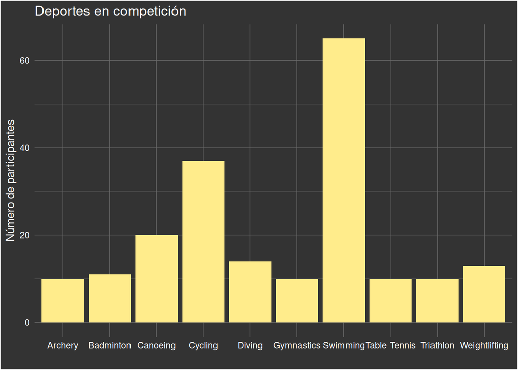

```r
df_sports <- ds_olimpicos[, c("Sport")]
df_sports_count <- df_sports %>%
  group_by(Sport) %>%
  summarise(count = n())


diag_barra <- ggplot(df_sports_count, mapping=aes(x = Sport, y=count)) +
 geom_col(fill = "#FFEC8B") +
 labs(
   title = "Deportes en competición",
   x = "",
   y = "Número de participantes") +
theme_dark() +
theme(
  plot.background = element_rect(fill = "gray20"),
  panel.background = element_rect(fill = "gray20"),
  axis.text = element_text(color = 'white'),
  axis.title = element_text(color = 'white'),
  title = element_text(color = 'white')
)
diag_barra
```

Se nota que la moda de Natación es la que más participantes tiene en la competición.

## 5. Diagrama de caja y bigotes para sexo y pesos

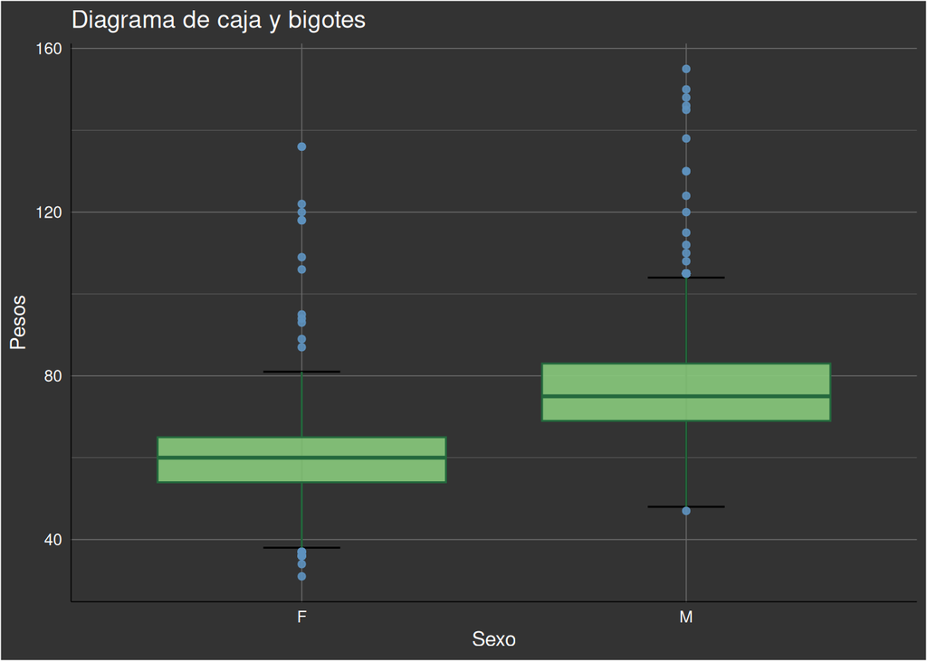

```r
  library(ggplot2)


ggplot(data = d_olimpicos, aes(x = Sex, y = Weight)) +
  stat_boxplot(geom = "errorbar",
               width = 0.2) +
  geom_boxplot(fill = "#88CA7C", colour = "#24693D",
               alpha = 0.9, outlier.colour = "#5D91BD") +
  scale_y_continuous(name = "Pesos") +
  scale_x_discrete(name = "Sexo") +
  ggtitle("Diagrama de caja y bigotes") +
  theme_dark() +
  theme(
    axis.line = element_line(colour = "black",size = 0.25),
    plot.background = element_rect(fill = "gray20"),
    panel.background = element_rect(fill = "gray20"),
    axis.text = element_text(color = 'white'),
    axis.title = element_text(color = 'white'),
    title = element_text(color = 'white')
)
```

Se observa que los hombres tienen un rango de pesos más amplio que las mujeres, además de que la mediana de los hombres es mayor que la de las mujeres.

## 6. Resúmen completo de altura por sexo

```r
df_sexo_altura <- ds_olimpicos[, c("Sex", "Height")]
df_sexo_altura_n <- df_sexo_altura %>%
  group_by(Sex) %>%
  summarise(mean_height = mean(Height),
      median_height = median(Height),
      min_height = min(Height),
      max_height = max(Height),
      mode_height = ds_mode(Height))

df_sexo_altura_n
```

| Sex | mean_height | median_height | min_height | max_height | mode_height |
| --- | --- | --- | --- | --- | --- |
| F | 167.3205 | 168 | 144 | 187 | 165 |
| M | 180.0820 | 180 | 154 | 206 | 175 |

```r
if (FALSE) {

# Generar la tabla con kable
kable(df_sexo_altura_n,
      caption = "Altura por sexo",
      col.names = c("Sexo", "Media", "Mediana", "Minimo", "Maximo", "Moda"),
      align = "c")
}
```

Se observa que la altura promedio de los hombres es mayor que la de las mujeres, además de que la mediana de los hombres es mayor que la de las mujeres. También el rango de las alturas de los hombres es más amplio que el de las mujeres.

## 7. Tabla de frecuencias para la altura de las mujeres

```r
df_mujer_altura <- ds_olimpicos[, c("Sex", "Height")]
df_mujer_altura <- filter(df_mujer_altura,Sex=="F")

if (FALSE) {


df_mujer_altura_n <- df_mujer_altura %>%
  group_by(Sex,Height) %>%
  summarise(count = n())

df_mujer_altura
}

altura_minima <- min(df_mujer_altura$Height)
altura_maxima <- max(df_mujer_altura$Height)

amplitud_intervalo <- 4

intervalos <- seq(altura_minima, altura_maxima, by = amplitud_intervalo)

frecuencia_absoluta <- cut(df_mujer_altura$Height, breaks = intervalos, right = FALSE)

tabla_frecuencia <- table(frecuencia_absoluta)
as.data.frame.array(tabla_frecuencia)
```

|  | tabla_frecuencia |
| --- | --- |
| [144,148) | 2 |
| [148,152) | 1 |
| [152,156) | 4 |
| [156,160) | 5 |
| [160,164) | 9 |
| [164,168) | 17 |
| [168,172) | 16 |
| [172,176) | 13 |
| [176,180) | 6 |
| [180,184) | 2 |

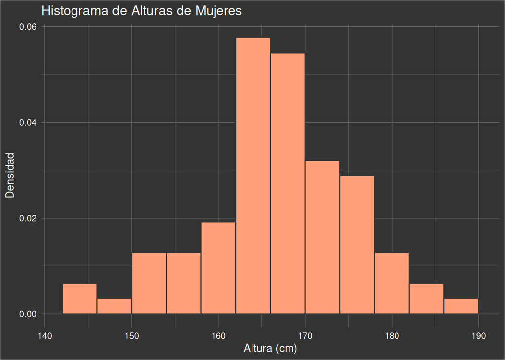

```r
frecuencia_relativa <- prop.table(tabla_frecuencia)


if (FALSE) {

ggplot(df_mujer_altura_n, aes(x = Height, y = count)) +
  geom_bar(stat = "identity", fill = "steelblue") +
  labs(title = "Frecuencia de altura por mujer", x = "Altura", y = "Count") +
  theme_minimal()
}

#histograma con frecuencia relativa
ggplot(df_mujer_altura, aes(x = Height)) +
  geom_histogram(aes(y = ..density..), fill = "#FFA07A", color = "gray20", binwidth = 4) +
  labs(title = "Histograma de Alturas de Mujeres",
       x = "Altura (cm)", y = "Densidad") +
  theme_dark() +
  theme(
  plot.background = element_rect(fill = "gray20"),
  panel.background = element_rect(fill = "gray20"),
  axis.text = element_text(color = 'white'),
  axis.title = element_text(color = 'white'),
  title = element_text(color = 'white')
)
```

El intervalo de alturas más denso para las mujeres es de 164 cm a 168 cm y el rango menos denso es de 148 cm a 152cm.

## 8. Conclusiones

### Número total de países participantes por sexo

De acuerdo con los resultados, hubo un total de 122 participantes hombres y 78 participantes mujeres en estos Juegos Olímpicos. Esto refleja una brecha de género significativa en la representación deportiva en estos Juegos Olímpicos, lo cual podría indicar la necesidad de promover una mayor equidad e inclusión de atletas femeninas en el ámbito deportivo de alto rendimiento.

### Diagrama de barras para los deportes en competición

El diagrama de barras muestra la cantidad de participantes por deporte. Se puede ver que los deportes con más participantes fueron Natación, Cicclismo y Canotaje Esto indica cuáles fueron las disciplinas más populares y con mayor representación en estos Juegos Olímpicos.

### Diagrama de caja y bigotes para sexo y pesos

El diagrama de caja y bigotes muestra que, en general, los hombres tienen pesos más altos que las mujeres. Además, se puede observar que hay más variabilidad en los pesos de los hombres en comparación con las mujeres.

### Resumen completo de altura por sexo

El resumen muestra que la altura promedio de las mujeres participantes fue de 167 cm, mientras que la de los hombres fue de 180 cm. Además, se pueden ver otras medidas como la mediana, el mínimo, el máximo y la moda de las alturas para cada sexo.